# Adaboost and Gradient Boosting Training

Nguyen Hai Truong & Nguyen Minh Thanh

May 22, 2017

# 1 Lý thuyết

## 1.1 So sánh với Bagging

**Bagging** dùng bootstrap để lấy ngẫu nhiên các tập con từ tập train ban đầu, sau đó xây dựng cây quyết định với mỗi tập con đó (các cây hoàn toàn độc lập với nhau), rồi kết hợp tất cả các cây lại để tạo ra 1 mô hình dự báo (bằng cách lấy trung bình hoặc bình chọn theo số đông các kết quả dự báo từ các cây quyết định nói trên).

**Boosting** hoạt động theo cách tương tự, trừ việc các cây quyết định được xây dựng “sequentially”: Mỗi cây kế tiếp được xây dựng bằng cách sử dụng kết quả từ những cây trước đó. Boosting tập trung nhiều hơn vào những quan sát bị dự báo sai từ những cây trước để góp phần cải thiện chất lượng dự báo của mô hình cuối cùng. Boosting không dùng bootstrap sampling, mà thay vào đó là việc dùng modified version của tập train ban đầu.

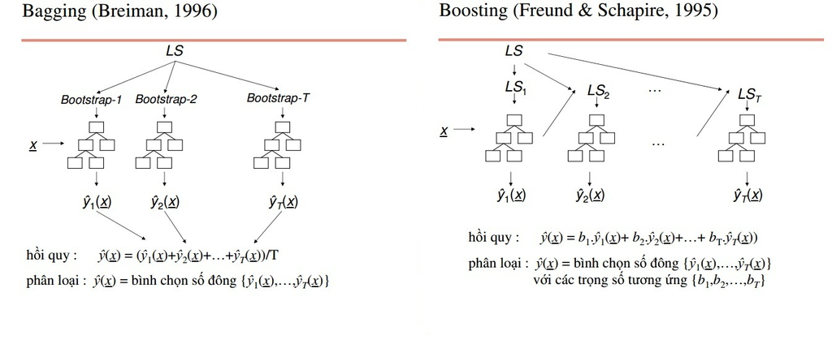

## 1.2 Các thuật toán Boosting

Một số loại thuật toán Boosting tiêu biểu:

- AdaBoost (**Ada**ptive **Boost**ing)
- Gradient Boosting
- XGBoost (E**x**treme **G**radient **Boost**ing)

### 1.2.1 AdaBoost

**AdaBoost** kết hợp các cây phân loại “yếu” để tạo thành cây phân loại “mạnh” (cây phân loại “yếu” là cây phân loại tốt hơn 1 chút so với random guessing). Sau mỗi bước lặp, những quan sát bị phân loại sai sẽ được đánh trọng số cao hơn, những quan sát được phân loại đúng sẽ đánh trọng số thấp hơn. Mỗi cây tiếp theo được xây dựng với mục tiêu phân loại đúng những quan sát đã bị phân loại sai ở cây trước đó.

#### 1.2.1.1 Ví dụ

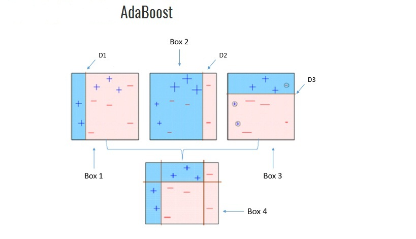

**Diễn giải**:

- Box 1: Đánh trọng số bằng nhau đối với tất cả quan sát và build một “decision stump” - D1 (cây chỉ gồm 1 split) để phân loại các quan sát thành 2 nhóm “+” và “-”. Kết quả cho thấy có 3 quan sát bị phân loại sai (là “+” nhưng lại bị cho vào nhóm “-”), 3 quan sát này sẽ được đánh trọng số cao hơn và tiếp tục build decision stump khác - D2.
- Box 2: D2 được build với mục đích phân loại đúng 3 quan sát bị phân loại sai ở D1. Kết quả cho thấy, lại có 3 quan sát bị phân loại sai (là “-” nhưng bị cho vào nhóm “+”). Lại tiếp tục đánh trọng số cao hơn đối với những quan sát này và tiếp tục build decision stump - D3.
- Box 3: D3 được build với mục đích phân loại đúng 3 quan sát bị phân loại sai ở D2. Kết quả cho thấy vẫn có những quan sát bị phân loại sai.
- Box 4: Kết hợp D1, D2, D3 để tạo thành D4 - phân loại tốt hơn so với D1, D2, D3 (nhóm “+” và “-” đã được phân loại hoàn toàn).

#### 1.2.1.2 Algorithm

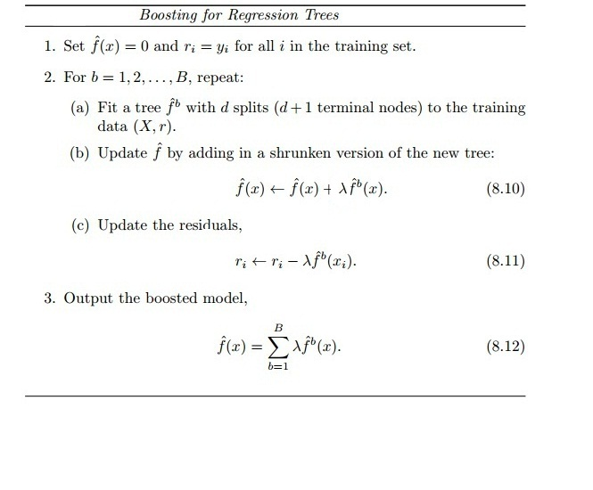

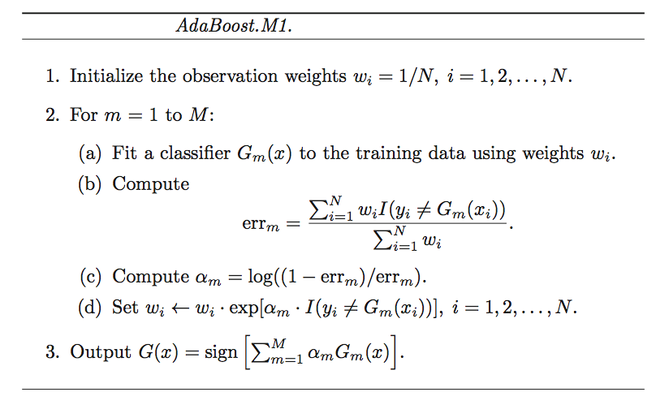

### 1.2.2 Gradient Boosting

Gradient Boosting = Gradient Descent + Boosting

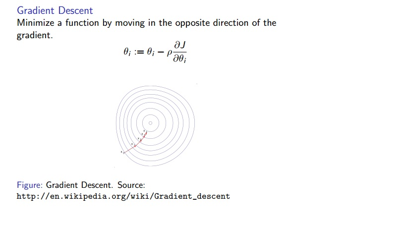

Cả AdaBoost và Gradient Boosting đều kết hợp các “weak learner” để tạo thành một “strong learner” và đều tập trung vào những quan sát bị dự báo sai. AdaBoost thì đánh trong số cao hơn vào những quan sát bị dự báo sai tại mỗi cây trước, và cố gắng dự báo đúng những quan sát đó tại cây tiếp theo. Trong khi đó, với Gradient Boosting, mỗi một cây mới sẽ được xây dựng với mục tiêu minimizes dần tổng loss của cây trước đó bằng việc sử dụng phương pháp gradient descent.

Trong Gradient Boosting, việc tính tổng loss dựa vào việc lựa chọn loại “loss function” nào, ví dụ như: square loss, absolute loss, huber loss. Mỗi loại đều có những ưu/nhược điểm riêng.

**Square loss**:

$$L(y,F) = (y-F)^2/2$$

**Absolute loss**:

$$L(y,F) = |y-F|$$

**Huber loss**:

$$\begin{cases}(y-F)^2/2 & |x-F| \leqslant \delta\\\delta(|y-F| - \delta/2) & |x-F| > \delta\end{cases}$$

**Ví dụ**:

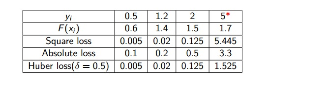

#### 1.2.2.1 Algoritm

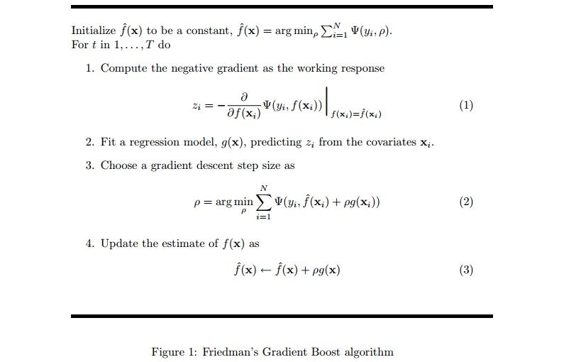

## 1.3 Tuning parameters

- **Số lượng cây** (B): Không giống như Bagging & Random forests, Boosting có thể bị overfitting nếu như B quá lớn. Chúng ta sử dụng cross-validation để lựa chọn B.
- **The shrinkage parameter/learning rate** (λ > 0): giá trị mặc định thường là 0.001. Nếu chọn λ quá nhỏ thì sẽ yêu cầu giá trị B rất lớn để đạt được chất lượng mô hình tốt.
- **Interaction depth** (d): limits depth of each tree - số tầng/splits của mỗi cây.

# 2 Thực hành với R

## 2.1 Data

Sử dụng data $GermanCredit$

Đây là data ghi nhận về lịch sử vay của khách hàng, với các 61 biến cùng với biến Class ghi nhận thực tế là các khoản vay đó có phải là khoản nợ xấu hay không.

```r
rm(list = ls())
data("GermanCredit")
data <- GermanCredit
rm(GermanCredit)
#Function cho tính toán chỉ số mô hình
model.performance <- function(confusion_matrix) {
  a <- confusion_matrix[1,1]
  b <- confusion_matrix[1,2]
  c <- confusion_matrix[2,2]
  d <- confusion_matrix[2,1]

  tpr <- c/(b+c)
  precision <- c/(c+d)
  accuracy <- (a+c)/(a+b+c+d)

  print(paste('tpr :',round(tpr,2)))
  print(paste('precision :', round(precision,2)))
  print(paste('accuracy :',round(accuracy,2)))
  }
#Chia data
set.seed(123)
indxTrain <- createDataPartition(y = data$Class,p = 8/10,list = FALSE)
training <- data[indxTrain,]
testing <- data[-indxTrain,]

df.train <- training
df.train$Status[df.train$Class == "Good"] <- 1
df.train$Status[df.train$Class == "Bad"] <- 0


df.test <- testing
df.test$Status[df.test$Class == "Good"] <- 1
df.test$Status[df.test$Class == "Bad"] <- 0
```

## 2.2 Adaboost

### 2.2.1 VD1

Như chúng ta đã biết, mỗi mô hình với các tuning parameter khác nhau sẽ cho các mô hình khác nhau, ta sẽ xây mô hình đầu tiên với parameter như sau:

- Số cây quyết định: 1000
- Learning rate: 0.01
- Số tầng của cây: 4

#### 2.2.1.1 Build mô hinh adaboost trên tập train

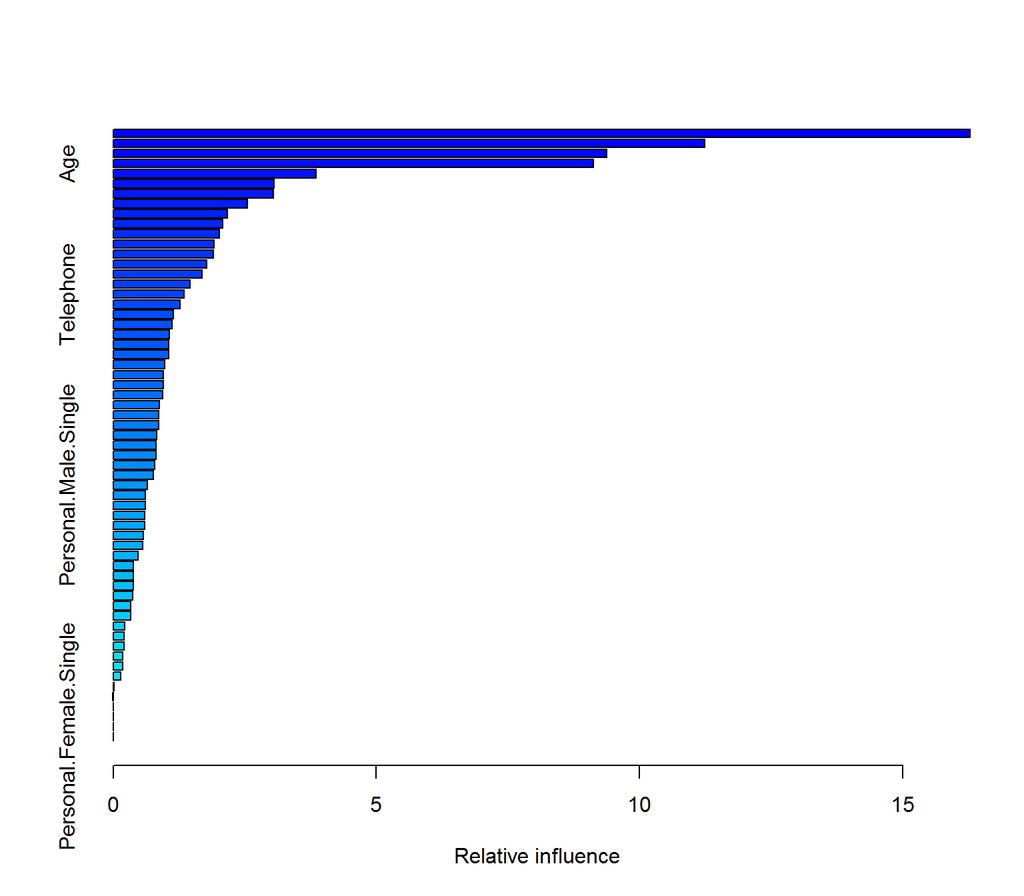

```
##                                                                           var
## Amount                                                                 Amount
## Duration                                                             Duration
## CheckingAccountStatus.none                         CheckingAccountStatus.none
## Age                                                                       Age
## CheckingAccountStatus.lt.0                         CheckingAccountStatus.lt.0
## InstallmentRatePercentage                           InstallmentRatePercentage
## CreditHistory.Critical                                 CreditHistory.Critical
## Purpose.NewCar                                                 Purpose.NewCar
## ResidenceDuration                                           ResidenceDuration
## SavingsAccountBonds.lt.100                         SavingsAccountBonds.lt.100
## SavingsAccountBonds.Unknown                       SavingsAccountBonds.Unknown
## OtherInstallmentPlans.None                         OtherInstallmentPlans.None
## CreditHistory.ThisBank.AllPaid                 CreditHistory.ThisBank.AllPaid
## Purpose.Education                                           Purpose.Education
## OtherInstallmentPlans.Bank                         OtherInstallmentPlans.Bank
## Purpose.UsedCar                                               Purpose.UsedCar
## Telephone                                                           Telephone
## EmploymentDuration.lt.1                               EmploymentDuration.lt.1
## CreditHistory.NoCredit.AllPaid                 CreditHistory.NoCredit.AllPaid
## NumberPeopleMaintenance                               NumberPeopleMaintenance
## NumberExistingCredits                                   NumberExistingCredits
## OtherDebtorsGuarantors.CoApplicant         OtherDebtorsGuarantors.CoApplicant
## CreditHistory.Delay                                       CreditHistory.Delay
## EmploymentDuration.4.to.7                           EmploymentDuration.4.to.7
## Property.RealEstate                                       Property.RealEstate
## OtherDebtorsGuarantors.Guarantor             OtherDebtorsGuarantors.Guarantor
## Housing.Rent                                                     Housing.Rent
## CheckingAccountStatus.0.to.200                 CheckingAccountStatus.0.to.200
## Property.Unknown                                             Property.Unknown
## CreditHistory.PaidDuly                                 CreditHistory.PaidDuly
## Job.Management.SelfEmp.HighlyQualified Job.Management.SelfEmp.HighlyQualified
## Property.Insurance                                         Property.Insurance
## Housing.Own                                                       Housing.Own
## Purpose.Radio.Television                             Purpose.Radio.Television
## Purpose.Business                                             Purpose.Business
## Personal.Male.Single                                     Personal.Male.Single
## Personal.Female.NotSingle                           Personal.Female.NotSingle
## EmploymentDuration.Unemployed                   EmploymentDuration.Unemployed
## OtherDebtorsGuarantors.None                       OtherDebtorsGuarantors.None
```

[output cut: 69 more lines]

```
## EmploymentDuration.1.to.4               0.367345387
## Purpose.Furniture.Equipment             0.337988761
## Property.CarOther                       0.333559968
## Purpose.Repairs                         0.216533880
## ForeignWorker                           0.204794720
## Housing.ForFree                         0.200946068
## SavingsAccountBonds.500.to.1000         0.181891758
## SavingsAccountBonds.gt.1000             0.176521610
## Personal.Male.Married.Widowed           0.140203181
## Job.UnemployedUnskilled                 0.011512843
## Purpose.Other                           0.007958265
## Purpose.DomesticAppliance               0.000000000
## Purpose.Vacation                        0.000000000
## Purpose.Retraining                      0.000000000
## Personal.Female.Single                  0.000000000
```

```r
#adaboost
set.seed(9999)
ada.train <- gbm(Status ~ . - Class,
      data = df.train,
      distribution = "adaboost",
      n.trees = 1000,
      shrinkage = 0.01,
      interaction.depth = 4)
ada.train %>% summary
```

#### 2.2.1.2 Áp dụng mô hình adaboost trên tập test

```r
ada.result <- predict(ada.train,
                      newdata = df.test,
                      n.trees = 1000,
                      type = "response")
```

#### 2.2.1.3 Confusion Matrix

```r
#confusion matrix
ada.conf  <-  rep ("Bad", 200)
ada.conf[ada.result >= 0.5] = "Good"
confusion <- table(ada.conf, df.test$Class)
confusion
```

```
##
## ada.conf Bad Good
##     Bad   33   16
##     Good  27  124
```

#### 2.2.1.4 ROC và AUC

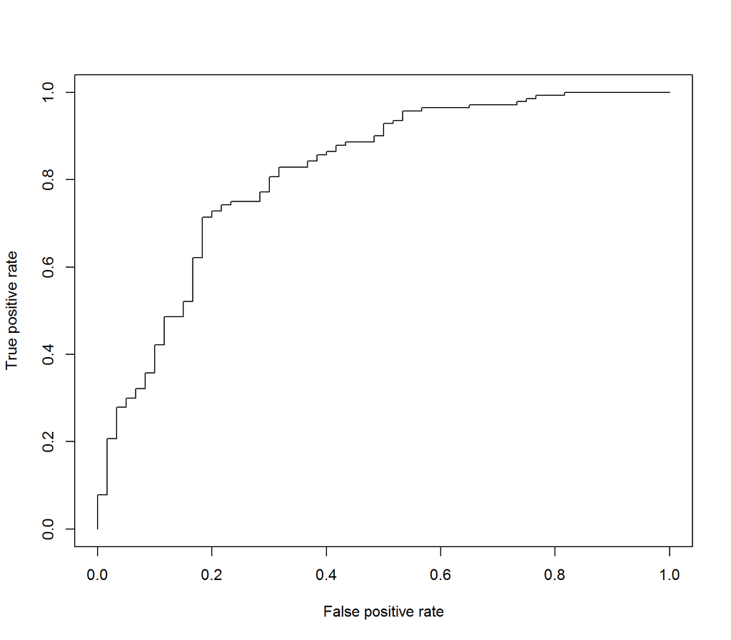

```r
#ROC
ROC <- prediction(ada.result, df.test$Class)
ROCperf_test <- performance(ROC, "tpr", "fpr")
plot(ROCperf_test)
```

```r
auc_test <- performance(ROC, "auc", "cutoff")
auc_test@y.values
```

```
## [[1]]
## [1] 0.8163095
```

### 2.2.2 VD2

Ta thay đổi tuning parameter như sau để ra một model mới

- Số cây quyết định: 1000
- Learning rate: 0.001
- Số tầng của cây: 4

#### 2.2.2.1 Build mô hinh adaboost trên tập train

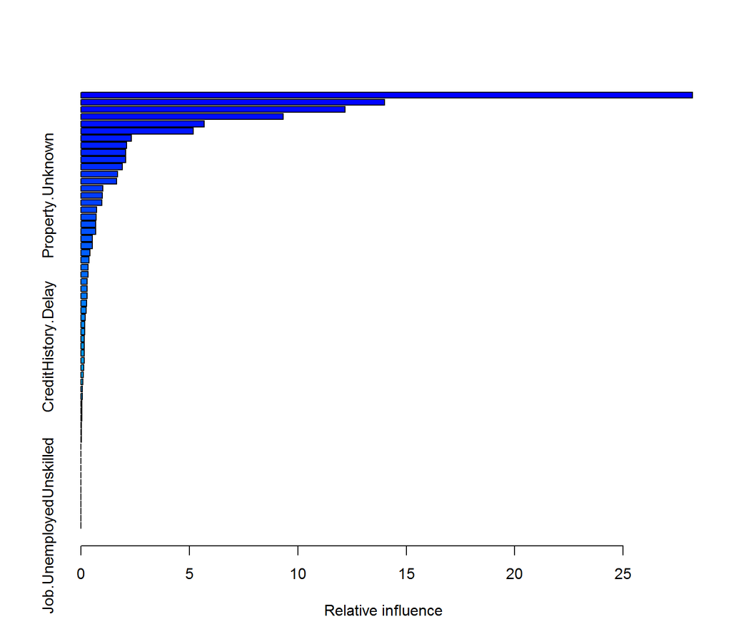

```
##                                                                           var
## CheckingAccountStatus.none                         CheckingAccountStatus.none
## Duration                                                             Duration
## Amount                                                                 Amount
## CheckingAccountStatus.lt.0                         CheckingAccountStatus.lt.0
## CreditHistory.Critical                                 CreditHistory.Critical
## Age                                                                       Age
## CreditHistory.ThisBank.AllPaid                 CreditHistory.ThisBank.AllPaid
## OtherInstallmentPlans.None                         OtherInstallmentPlans.None
## SavingsAccountBonds.lt.100                         SavingsAccountBonds.lt.100
## InstallmentRatePercentage                           InstallmentRatePercentage
## SavingsAccountBonds.Unknown                       SavingsAccountBonds.Unknown
## OtherInstallmentPlans.Bank                         OtherInstallmentPlans.Bank
## Purpose.NewCar                                                 Purpose.NewCar
## CreditHistory.NoCredit.AllPaid                 CreditHistory.NoCredit.AllPaid
## Property.Unknown                                             Property.Unknown
## OtherDebtorsGuarantors.Guarantor             OtherDebtorsGuarantors.Guarantor
## Purpose.UsedCar                                               Purpose.UsedCar
## Property.RealEstate                                       Property.RealEstate
## Housing.Own                                                       Housing.Own
## OtherDebtorsGuarantors.None                       OtherDebtorsGuarantors.None
## Purpose.Business                                             Purpose.Business
## CheckingAccountStatus.gt.200                     CheckingAccountStatus.gt.200
## Housing.Rent                                                     Housing.Rent
## CheckingAccountStatus.0.to.200                 CheckingAccountStatus.0.to.200
## Telephone                                                           Telephone
## Purpose.Education                                           Purpose.Education
## Purpose.Radio.Television                             Purpose.Radio.Television
## CreditHistory.PaidDuly                                 CreditHistory.PaidDuly
## ResidenceDuration                                           ResidenceDuration
## EmploymentDuration.lt.1                               EmploymentDuration.lt.1
## Job.Management.SelfEmp.HighlyQualified Job.Management.SelfEmp.HighlyQualified
## Job.SkilledEmployee                                       Job.SkilledEmployee
## NumberExistingCredits                                   NumberExistingCredits
## EmploymentDuration.gt.7                               EmploymentDuration.gt.7
## Personal.Female.NotSingle                           Personal.Female.NotSingle
## CreditHistory.Delay                                       CreditHistory.Delay
## Job.UnskilledResident                                   Job.UnskilledResident
## Personal.Male.Single                                     Personal.Male.Single
## OtherDebtorsGuarantors.CoApplicant         OtherDebtorsGuarantors.CoApplicant
```

[output cut: 69 more lines]

```
## EmploymentDuration.1.to.4               0.03668949
## SavingsAccountBonds.gt.1000             0.01929204
## Personal.Male.Divorced.Seperated        0.01848142
## ForeignWorker                           0.00000000
## Purpose.DomesticAppliance               0.00000000
## Purpose.Repairs                         0.00000000
## Purpose.Vacation                        0.00000000
## Purpose.Retraining                      0.00000000
## Purpose.Other                           0.00000000
## SavingsAccountBonds.500.to.1000         0.00000000
## Personal.Male.Married.Widowed           0.00000000
## Personal.Female.Single                  0.00000000
## OtherInstallmentPlans.Stores            0.00000000
## Housing.ForFree                         0.00000000
## Job.UnemployedUnskilled                 0.00000000
```

```r
#adaboost
set.seed(9999)
new.ada.train <- gbm(Status ~ . - Class,
                     data = df.train,
                     distribution = "adaboost",
                     n.trees = 1000,
                     shrinkage = 0.001,
                     interaction.depth = 4)      #the depth of each tree (complexity)
new.ada.train %>% summary
```

#### 2.2.2.2 Áp dụng mô hình adaboost trên tập test

```r
new.ada.result <- predict(new.ada.train,
                          newdata = df.test,
                          n.trees = 1000,
                          type = "response")
```

#### 2.2.2.3 Confusion Matrix

```r
#confusion matrix
new.ada.conf  <-  rep ("Bad", 200)
new.ada.conf[new.ada.result > 0.5] = "Good"
new.confusion <- table(new.ada.conf, df.test$Class)
new.confusion
```

```
##
## new.ada.conf Bad Good
##         Good  60  140
```

#### 2.2.2.4 ROC và AUC

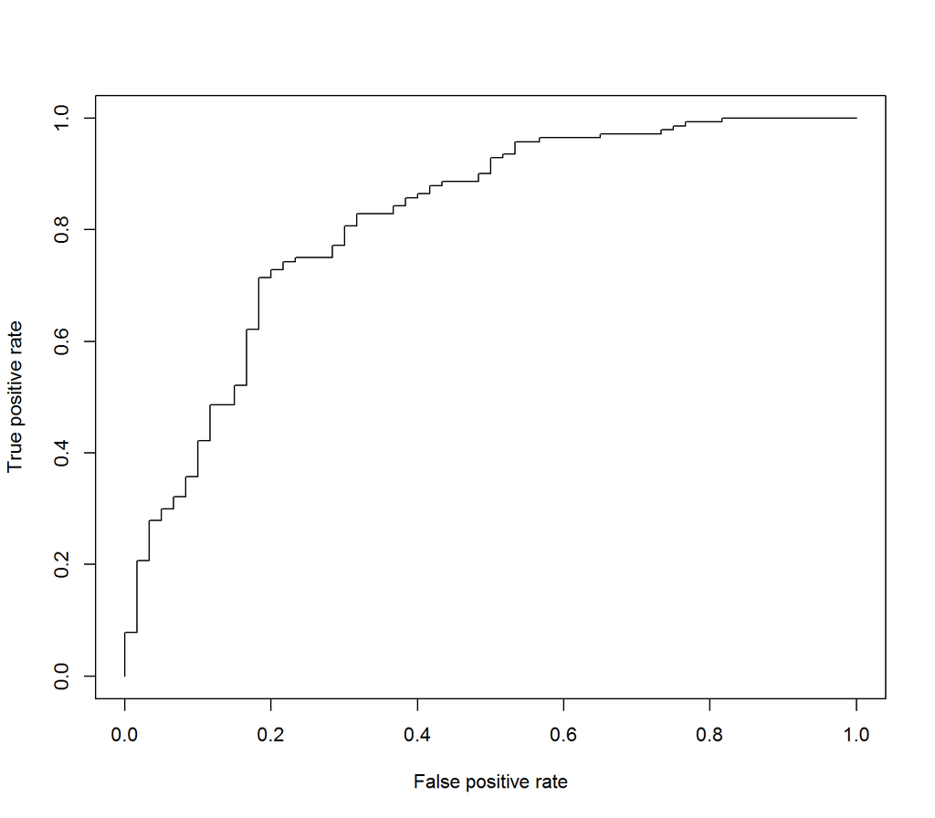

```r
#ROC
new.ROC <- prediction(new.ada.result, df.test$Class)
new.ROCperf_test <- performance(ROC, "tpr", "fpr")
plot(new.ROCperf_test)
```

```r
new.auc_test <- performance(new.ROC, "auc", "cutoff")
new.auc_test@y.values
```

```
## [[1]]
## [1] 0.7777381
```

Từ 2 adaboost model ta nhận thấy mô hình đầu tiên có chỉ số AUC lớn hơn (0.82 so với 0.78), do vậy mô hình đầu tiên sẽ là mô hình được sử dụng để dự báo nợ xấu của khách hàng

Ngoài ra có mộ số chỉ số khác của mô hình như sau

```r
model.performance(confusion)
```

```
## [1] "tpr : 0.89"
## [1] "precision : 0.82"
## [1] "accuracy : 0.78"
```

## 2.3 Gradient Boosting

### 2.3.1 VD1

Tương tự như với Adaboost, đầu tiên ta sẽ sử dụng parameter như sau

- Số cây quyết định: 1000
- Learning rate: 0.01
- Số tầng của cây: 4

#### 2.3.1.1 Confusion matrix

```r
#Gradient Boosting
set.seed(9999)
gbm.train <- gbm(Status ~ . - Class,
                 data = df.train,
                 distribution = "bernoulli",
                 n.trees = 1000,
                 shrinkage = 0.01,
                 interaction.depth = 4)
gbm.result <- predict(gbm.train,
                      newdata = df.test,
                      n.trees = 1000,
                      type = "response")

#confusion matrix
gbm.conf  <-  rep ("Bad", 200)
gbm.conf[gbm.result > 0.5] = "Good"
gbm.confusion <- table(gbm.conf, df.test$Class)
gbm.confusion
```

```
##
## gbm.conf Bad Good
##     Bad   35   16
##     Good  25  124
```

#### 2.3.1.2 ROC và AUC

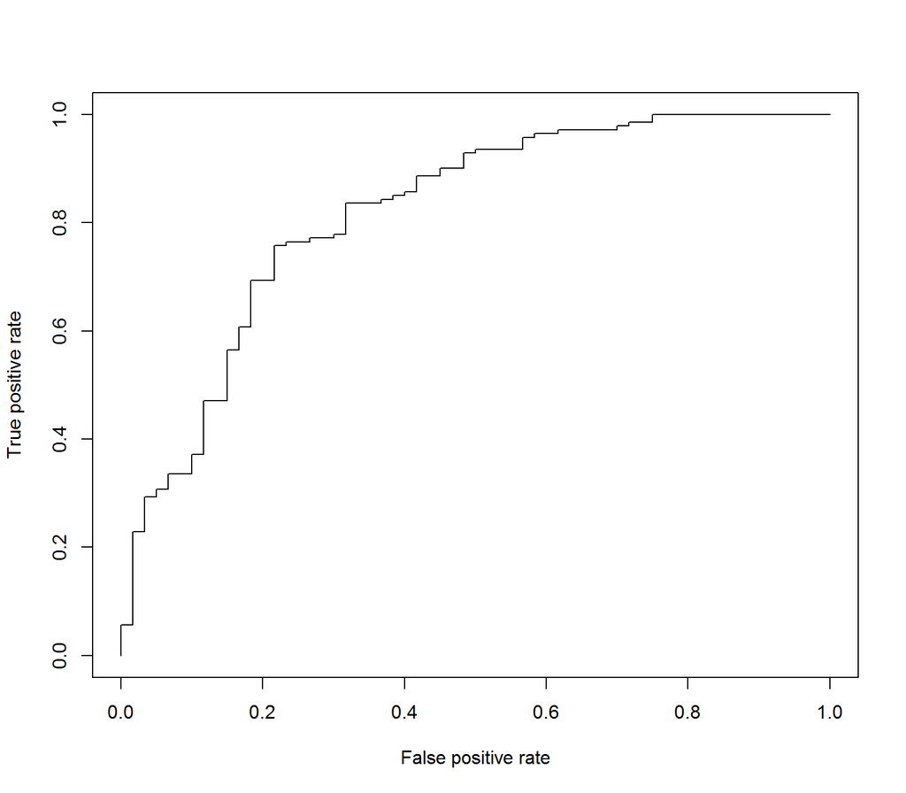

```r
#ROC
gbm.ROC <- prediction(gbm.result, df.test$Class)
gbm.ROCperf_test <- performance(gbm.ROC, "tpr", "fpr")
plot(gbm.ROCperf_test)
```

```r
gbm.auc_test <- performance(gbm.ROC, "auc", "cutoff")
gbm.auc_test@y.values
```

```
## [[1]]
## [1] 0.8171429
```

### 2.3.2 VD2

Ta sẽ sử dụng parameter như sau để so sánh chất lượng của 2 mô hình

- Số cây quyết định: 1000
- Learning rate: 0.001
- Số tầng của cây: 4

#### 2.3.2.1 Confusion matrix

```r
#Gradient Boosting
set.seed(9999)
new.gbm.train <- gbm(Status ~ . - Class,
                     data = df.train,
                     distribution = "bernoulli",
                     n.trees = 1000,
                     shrinkage = 0.001,
                     interaction.depth = 4)
new.gbm.result <- predict(new.gbm.train,
                          newdata = df.test,
                          n.trees = 1000,
                          type = "response")

#confusion matrix
new.gbm.conf  <-  rep ("Bad", 200)
new.gbm.conf[new.gbm.result > 0.5] = "Good"
new.gbm.confusion <- table(new.gbm.conf, df.test$Class)
new.gbm.confusion
```

```
##
## new.gbm.conf Bad Good
##         Bad    6    0
##         Good  54  140
```

#### 2.3.2.2 ROC và AUC

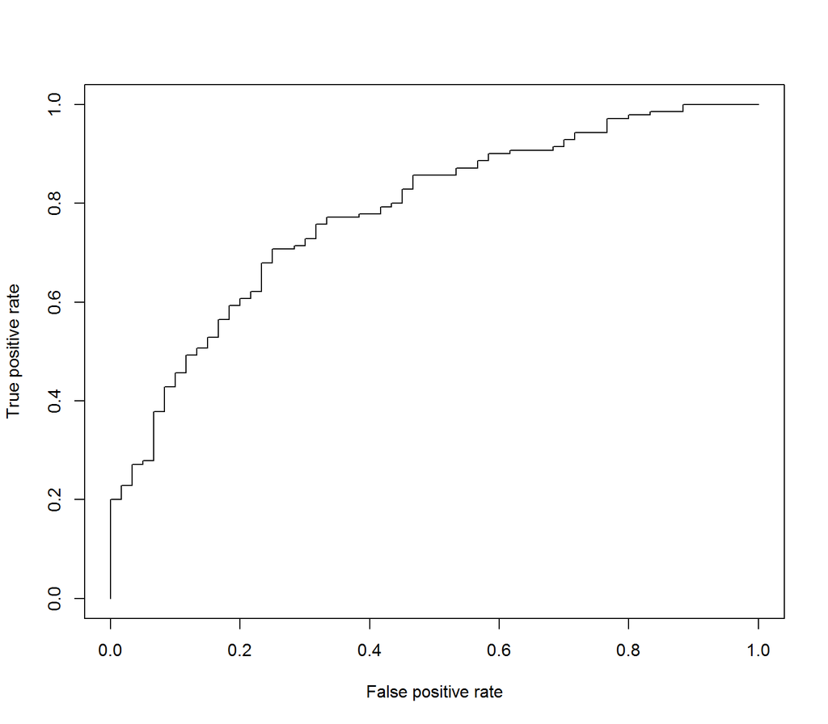

```r
#ROC
new.gbm.ROC <- prediction(new.gbm.result, df.test$Class)
new.gbm.ROCperf_test <- performance(new.gbm.ROC, "tpr", "fpr")
plot(new.gbm.ROCperf_test)
```

```r
new.gbm.auc_test <- performance(new.gbm.ROC, "auc", "cutoff")
new.gbm.auc_test@y.values
```

```
## [[1]]
## [1] 0.7792857
```

Kết quả so sánh cho thấy mô hình đầu tiên cho ta chỉ số AUC cao hơn, do vậy đây là mô hình Gradient Boosting tốt hơn để áp dụng vào việc dự báo

```r
model.performance(confusion)
```

```
## [1] "tpr : 0.89"
## [1] "precision : 0.82"
## [1] "accuracy : 0.78"
```

## 2.4 Áp dụng 2 mô hình vào bài toán kinh tế

Giả sử mỗi khách hàng vay 100USD, mỗi khách hàng dự báo là tốt sẽ mang lại 10% lợi nhuận tức 10USD còn với mỗi khách hàng nợ xấu sẽ mất toàn bộ số tiền cho vay. Ta cần so sánh lợi ích kinh tế của 2 mô hình

### 2.4.1 Lợi nhuận từ mô hình Adaboost

```r
table <- seq(0.11,0.98,0.01)
table <- table %>% as.data.frame()
names(table)[1] <- "cutoff"
for (i in seq(0.11,0.99,0.01)){
  ada.result
  ada.conf  <-  rep ("Bad", 200)
  ada.conf[ada.result >= i] = "Good"
  confusion <- table(ada.conf, df.test$Class)

  profit <- confusion[2,2]*10- confusion[2,1]*100
  cutoff <- i

  df <- cbind(cutoff, profit)
  df <- df %>% as.data.frame()

  table$benefit[table$cutoff %in% df$cutoff] <- df$profit
}

table
```

```
##    cutoff benefit
## 1    0.11   -4500
## 2    0.12   -4500
## 3    0.13   -4500
## 4    0.14   -4500
## 5    0.15   -4400
## 6    0.16   -4300
## 7    0.17   -4200
## 8    0.18   -4100
## 9    0.19   -4000
## 10   0.20   -4000
## 11   0.21   -3700
## 12   0.22   -3700
## 13   0.23   -3700
## 14   0.24   -3500
```

[output cut: 74 more lines]

### 2.4.2 Lợi nhuận từ mô hình Gradient Boosting

```r
table1 <- seq(0.13,0.98,0.01)
table1 <- table1 %>% as.data.frame()
names(table1)[1] <- "cutoff"
for (i in seq(0.13,0.98,0.01)){
  gbm.result
  gbm.conf  <-  rep ("Bad", 200)
  gbm.conf[gbm.result > i] = "Good"
  gbm.confusion <- table(gbm.conf, df.test$Class)

  profit <- gbm.confusion[2,2]*10- gbm.confusion[2,1]*100
  cutoff <- i

  df <- cbind(cutoff, profit)
  df <- df %>% as.data.frame()

  table1$benefit[table1$cutoff %in% df$cutoff] <- df$profit
}

table1
```

```
##    cutoff benefit
## 1    0.13   -4500
## 2    0.14   -4500
## 3    0.15   -4400
## 4    0.16   -4300
## 5    0.17   -4300
## 6    0.18   -4200
## 7    0.19   -4000
## 8    0.20   -3900
## 9    0.21   -3900
## 10   0.22   -3700
## 11   0.23   -3700
## 12   0.24   -3600
## 13   0.25   -3500
## 14   0.26   -3200
```

[output cut: 72 more lines]

Ta có thể thấy tại mô hình Adaboost với mức cutoff 0.95 thì lợi nhuận cực đại mang lại là 180USD còn với mô hình Gradient Boosting thì với mức cutff 0.93 lợi nhuận cực đại mang lại là 220USD. Do vậy, dựa vào lợi ích kinh tế thì mô hình Gradient Boosting sẽ là mô hình tốt hơn để dự báo.

# 3 Tài liệu tham khảo

- Introduction to Statistical Learning with R
- https://www.analyticsvidhya.com/blog/2015/05/boosting-algorithms-simplified/
- https://www.analyticsvidhya.com/blog/2015/11/quick-introduction-boosting-algorithms-machine-learning/
- https://www.analyticsvidhya.com/blog/2016/04/complete-tutorial-tree-based-modeling-scratch-in-python/#ten